# Study of the foreign-born population in the United States

**Here we conduct a brief study of the foreign-born population in the United States based on the American Community Survey (ACS) published by the Census Bureau. We use the person-level data published for 2014, which includes 3,134,610 individuals. We focus on the foreign-born population, identified using the “NATIVITY” variable in the data, which consists of 360,677 individuals.**

### Top 20 countries of origin for immigrants in the United States:

| Rank |  | Country | Immigrant Population |
| --- | --- | --- | --- |
| 1 |  | Mexico | 11.708 M |
| 2 |  | India | 2.181 M |
| 3 |  | Philippines | 1.921 M |
| 4 |  | China | 1.909 M |
| 5 |  | El Salvador | 1.307 M |
| 6 |  | Vietnam | 1.298 M |
| 7 |  | Cuba | 1.175 M |
| 8 |  | Korea | 1.08 M |
| 9 |  | Dominican Republic | 0.995 M |
| 10 |  | Guatemala | 0.905 M |
| 11 |  | Canada | 0.792 M |
| 12 |  | Jamaica | 0.708 M |
| 13 |  | Colombia | 0.696 M |
| 14 |  | Haiti | 0.617 M |
| 15 |  | Germany | 0.582 M |
| 16 |  | Honduras | 0.567 M |
| 17 |  | Peru | 0.44 M |
| 18 |  | Poland | 0.432 M |
| 19 |  | Ecuador | 0.419 M |
| 20 |  | Russia | 0.395 M |

###### (Icons: http://www.icondrawer.com)

### Geographic distribution of immigrant groups:

[interactive chart not shown]

### Age, Year of entry and Age of arrival of different immigrant groups:

We show the age distributions of five important immigrant groups (although not the five largest): Mexico, China, Cuba, India and Germany. These densities take into consideration the survey weights assigned to each observation.

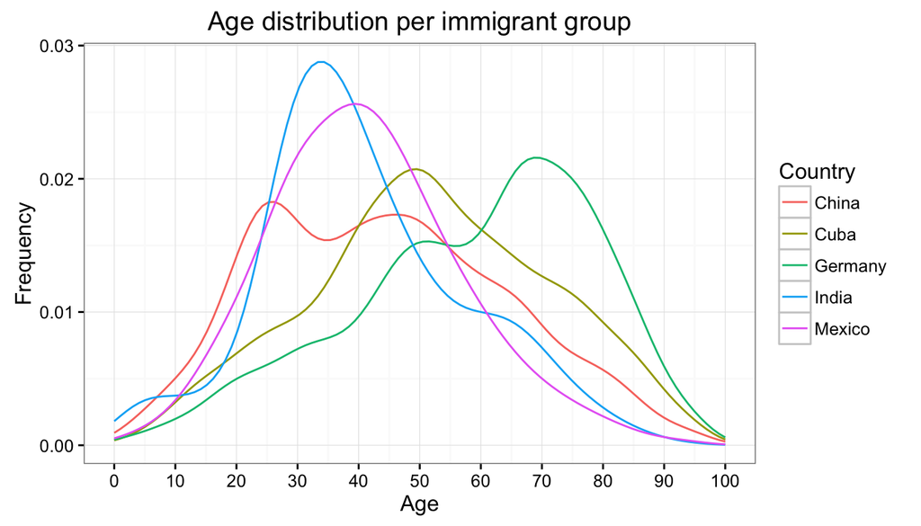

We notice that German immigrants tend to be significantly older than other groups, with a most likely age of about 70 years old. Cuban foreign-born residents are the second oldest group, with a typical age of about 50. In constrast, the bulk of Mexican and Indian immigrants tends to be in their thirties. Interestingly, the Chinese foreign-born population appears to have a bimodal distribution, with most idividuals either in their mid-twenties or in their forties.  
These age differences might be explained by the year in which each group entered the United States. We look at this next.

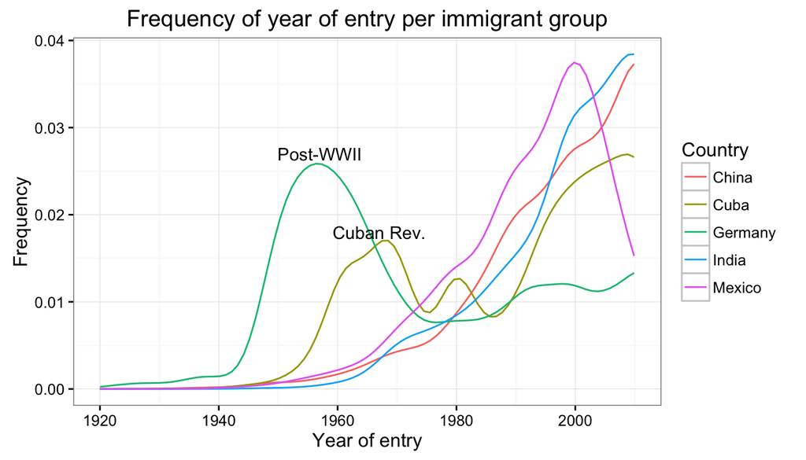

As suggested by the age distributions, we see that the large majority of the German group arrived in the coutry the earliest, in the two decades following World War II. The Cuban group followed, most likely pushed to exile by the revolution of 1953-59. We also see that the Mexican wave of immigration seems to have peaked around 2000, whereas Chinese and Indian immigration appears to not yet have reached its peak.  
Finally, we look at the distribution of the age of arrival, computed by subtracting the years since arrival (2014 - year-of-entry) to the current age.

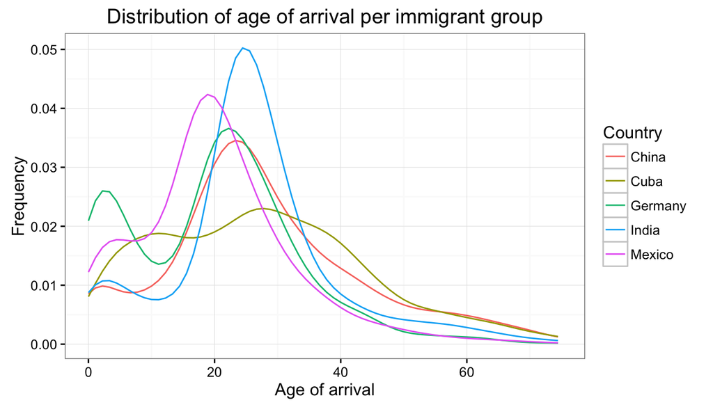

We see a general trend in most groups to immigrate to the country in their twenties. There is also evidence of a smaller mode at 0-10 years of age for most distributions, which suggests that a lot of foreign-born residents entered the country as small children.

### Now let’s talk about education!

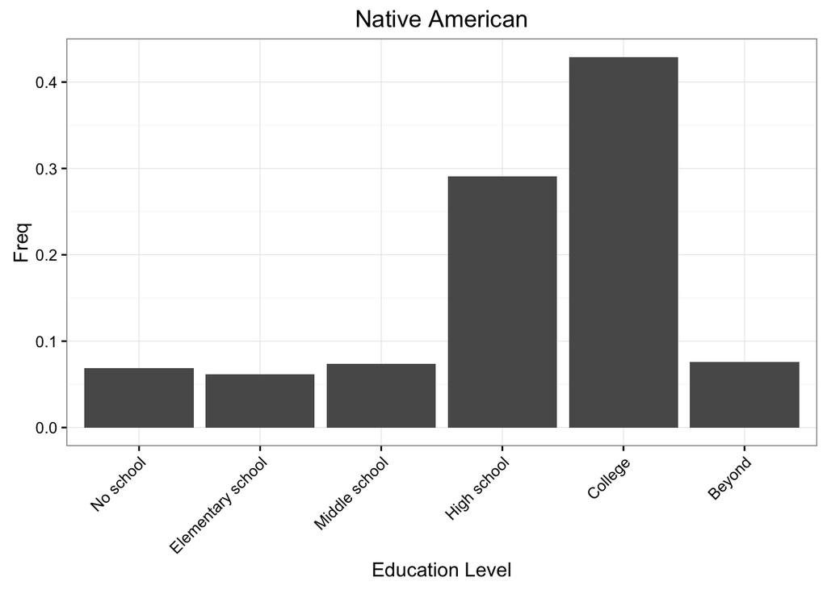

So as we can see here,most of the native Americans have went to college or have an associate degree or other certifications. And people who have went to high school and college add up to around 70 percent of the population. So let’s see what’s the scenario for other countries.

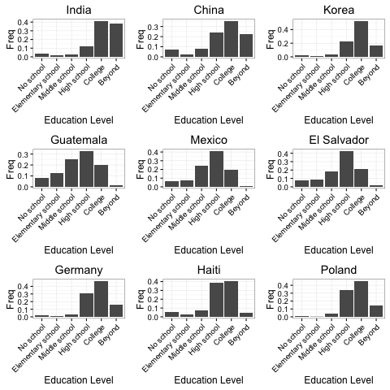

The graphs above are all from countries within our top 20 list. I’ve organized it a bit so that the first row is all Asian countries, and vast majority of Asian people in state posses a higher education degree, especially the percentage of people having a master or doctorate degree are around 20%, or even goes up to 40% like India, which is way higher than the native Americans. And as we see before, the era of Asian immigration has just began, a lot of well-educated Asian people are coming into US. We’ll see a bit more later.  
The second row is countries from America, the most common education background as we see in the graph is high school level. In the third row we got Germany and Poland from Europe, the distribution is kind of similar to Asian countries with most of the people in the college level, and a larger proportion of master and doctorate degrees.

|  | COB | mode_edu | Peak_immigration_Year | weighted_population | mode_age |
| --- | --- | --- | --- | --- | --- |
| 1 | Mexico | 16 | 2000 | 11707691 | 18 |
| 2 | India | 21 | 2013 | 2180809 | 25 |
| 3 | Philippines | 21 | 2007 | 1921306 | 25 |
| 4 | China | 21 | 2013 | 1908981 | 22 |
| 5 | El Salvador | 16 | 2000 | 1307217 | 20 |
| 6 | Vietnam | 16 | 1975 | 1297847 | 18 |
| 7 | Cuba | 16 | 1980 | 1175372 | 25 |
| 8 | Korea | 21 | 2000 | 1080225 | 0 |
| 9 | Dominican Republic | 16 | 1994 | 994836 | 17 |
| 10 | Guatemala | 16 | 2004 | 905321 | 19 |

[output cut: 50 more lines]

[interactive chart not shown]

In the upper right corner are the countries with more recent immigration peak and higher education level, which as we expect to have lots of Asian countries. It corresponds to the prior analysis that it’s the era of Asian immigration has just started :)  
‘We hold these truths to be self-evident, that all men are created equal.’ -Thomas Jefferson

### So do people from foreign countries really have an equal chance in getting education?

We took a look at the overall distribution of education level for foreign kid in United states.  
‘Foreign kid’ here are defined as those who came to US before age 6, the time when most native American kids start elementary school.

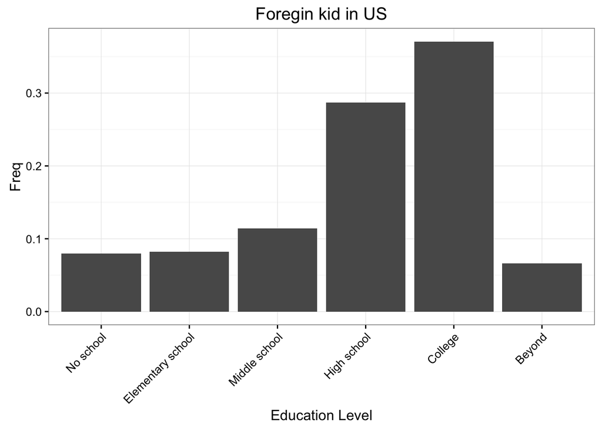

It looks pretty similar to the distribution of native American’s education level that we’ve shown before, but with a bit higher proportion in middle school and a bit lower in college, which is reasonable since a lot of young kids came to the states during the big wave of immigration around year 2000 - 2005, and by now they should have a middel school degree.  
Here we define another variable, the ‘drop out ratio’ Going to school especially elementary and middle school is very much like climbing a ladder. For example at age 6, you started with Grade 1, and most of the times you’ll be in Grade 2 at age 7. We define dropout as being a certain amount of years behind this ‘shedule’, in the extreme case, a 50 year old person whose education record is elementary school, we strongly believe that he has dropped out, and the drop out ratio would be the number of dropped out people divided by the population at the same education level Here we choose the amount of years to be 2, in consider for any gap year or later enrollment, then compare the drop out ratio between native and foregin kids.

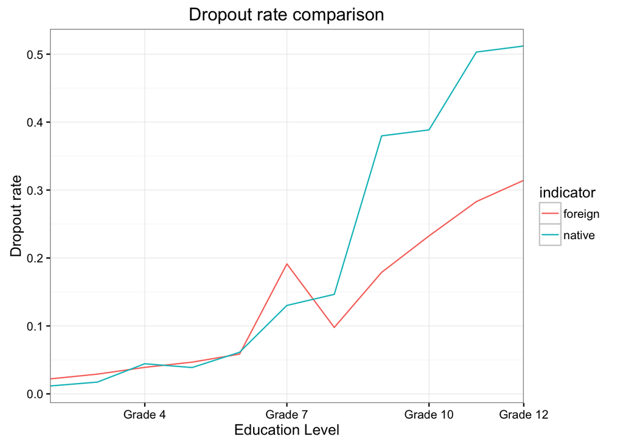

So it seems that drop out ratio is very similar during elementary school and middle school, but when going to high school the drop out rate went sky high for native American. My explanation would be that it’s quite common here in US to go back to school and get a degree after working a few years, and having a full-time job is not an option before high school, so the drop out ratio is rather close in that period.

### Let’s take a look at the employment status of the migrations in the U.S.

Firstly to choose the varaibles we are intersted in:

After comparing several similiar variables, we chose Class of Worker(COW),Employment Status Record(ESR) and Industry Field Record (INDP) as three attributes to evalute the employment situations of the immigrants in the U.S.

Then choose the countries we are interested in:

From the above picture, we can see that these are the top 20 countries migrant to the U.S. I picked Mexico, China, Cuba, Canada and Germany. As they are in South America, Asia, Middle America, North America and Europe, I think these five countries are representative. So I chose them as the our goals.

[figure not shown]

```
##
##     1     2     3     4     5     6
## 52489  1241  3855    61     3 29786
##
##    1    2    3    4    6
## 8909  288  531   20 7370
##
##    1    2    3    4    6
## 4853   93  382    9 4346
##
##    1    2    3    4    6
## 4118  149  201   10 3928
##
##    1    2    3    4    6
## 2489   74  128   14 3629
```

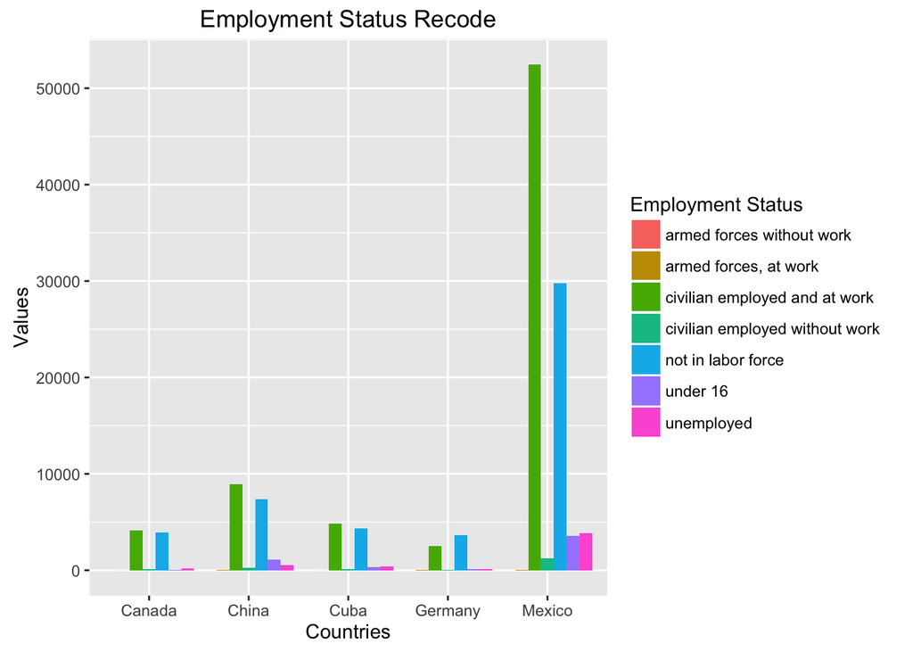

As we can see from the employment status recode graph, Mexican people surplus other countries of the total immigrants to the U.S. The civilian employed at work and not in labor force also take a large percentage. China ranks second and the other three countries all have the similar patterns, showing that people who are civilian employed and at work and not in labor force are the main status of the migrants in the U.S.

### Now let’s have a look at the immigrations’ income status.

When we want to know about the income status about the immigrants in the U.S, we chose the wage/salary income(WAGP) variable in the past year. We can divide them into nine class: Class 1:0 (no payment) Class 2: 0-20000 (0 is not included) Class 3:20000-40000 Class 4: 40000-60000 Class 5: 60000-80000 Class 6: 80000-100000 Class 7: 100000-150000 Class 8: >150000 Class 9: no record